# A journey through 71 years of Formula 1

Andrea Mansi - 137857 - Università degli Studi di Udine

February 15, 2021

# Introduction

In this presentation we will analize data about [Formula One](https://www.formula1.com/) history. We will explore data relating drivers, constructors, countries, circuits etc. involved in the history of this motorsport. We will try to find out which were the most dominant drivers and constructors in the history of Formula 1, evaluating their results taking into consideration more sophisticated criteria than the most classic ones. Statistics relating to the F1 itself, most iconic drivers, constructors and countries will also be shown. All the used data is available [here](https://www.kaggle.com/rohanrao/formula-1-world-championship-1950-2020) and consists of 13 csv files. Sourcecode is available [here](https://github.com/Mansitos/Progetto-DataScience-UNI-F1-Data-Analysis-R-Language)

## What is Formula One

Formula One (abbreviated to *F1*) is the highest class of international auto racing for single-seater racing car approved by the [Fédération Internationale de l’Automobile (FIA)](https://www.fia.com/). A Formula One season consists of a series of races, known as *Grands Prix*, which take place worldwide on purpose-built circuits and on closed public roads.

The results of each race are evaluated using a *points system* to determine two annual World Championships: one for drivers and one for constructors.

Formula One cars are considered the fastest regulated road-course racing cars in the world, haracterized by very high cornering speeds, achieved through the generation of large amounts of aerodynamic downforce. Most modern F1 cars can achieve peaks of 6.5 lateral g while cornering and approximately top speeds of 360km/h. Tracion control and other driving aids have been banned since 2008.

## Some history about F1

Formula One has its roots in the *European Grand Prix championships* of the 1920s and 1930s. The foundation of F1 began in 1946 with the FIA’s standardisations of rules, which was followed by the first *World Championships of Drivers* in 1950.

The history of Formula One is usually divided into eras, but this division is tipycally based on subjective criterias and there is no real official division. We will dive deep into the history of Formula One by introducing the most iconic drivers by querying the data and obtaining important results related to their careers, such as number of wins, number of podiums etc.

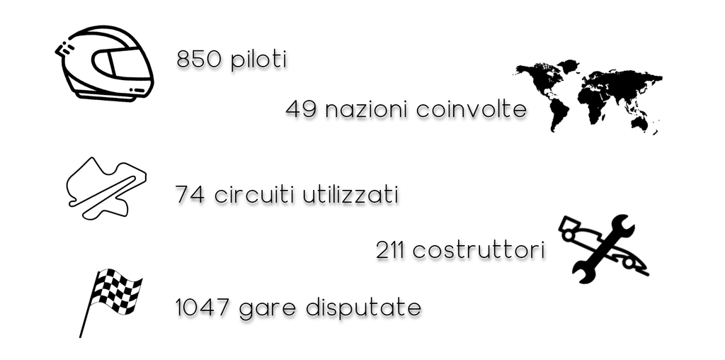

### First F1 winner

*“Because of the crazy way Farina drove only the Holy Virgin was capable of keeping him on the track.” - Juan Manuel Fangio*

### Domination of the 50s by Fangio & Ascari

Fangio’s records remained unbeaten for over 30 years. 1950s are remembered as the deadliest decade in F1, with 15 casualties. Helmetds became mandatory 2 years after the birth of F1, in 1952. Seatbelts became mandatory in 1972.

### The driver of the 1960s

The first driver to beat Fangio’s wins record was Jim Clark, a driver who dominated the circuits in the 1960s.

*“Jim Clarck was everything I aspired to be, as a racing driver and as a man” - Sir Jackie Stewart*

### The Flying Scot

Clark’s 25 wins record was broken by his greatest admirer: Sir John Jackie Stewart.

### The battle between teammates

It took 14 years to break Stewart’s winning record; a new one began, and the progenitor was Alain Prost.

A famous period of Formula One is the one called the Prost-Senna rivalry. The rivalry between the two pilots was at its most intense during the period in which they were teammates at McLaren (1988-1989).

Ayrton Seanna is probably the most loved driver in F1 history. Senna has distinguished himself throughout his career and was regarded as a prodigy driver who would break any records. Unfortunately Senna died aged 34 after a crash during the San Marino Grand Prix on 1 May 1994.

*“Racing, competing, it’s in my blood. It’s part of me, it’s part of my life; I have been doing it all my life and it stands out above everything else.” - Ayrton Senna*

### The Ferrari Era

One of the most iconic driver, if not the most iconic one, is Michael Schumacher, which during his career broke most of the records of this motorsport, settings a new standard which was beyond imagination.

*“I always thought records were there to be broken. - Michael Schumacher”*

### The Hybrid Era: the birth of a new legend

With the advent of the hybrid era (2014-present) was dominated by Mercedes and by his top driver Lewis Hamilton.

Hamilton is the first one to break Shumacher’s records and is currently considered the best F1 driver.

# Who is the most dominant driver of all time?

Which driver has dominated the circuits during the history of Formula One? It’s difficult to tell, but data can help us! Often drivers are compared taking into consideration only simple metrics, such as: *races won*, *world titles* and so on. Surely those metrics reflect the skill of the driver, however they are superficial evaluation criteria. For example, consider the case in which the driver *a* has won 100 races out of 500 and driver *b* has won 70 races out of 120. Would you still say that driver *a* is better than driver *b* just because he has won more races? The data collected during these 71 years can help us build a more advanced evaluation system, based on multiple parameters, which will allow us to evaluate drivers in a more transparent and objective way. Let’s start by showing some basic drivers summaries which we will use later for evaluating the performance of drivers.

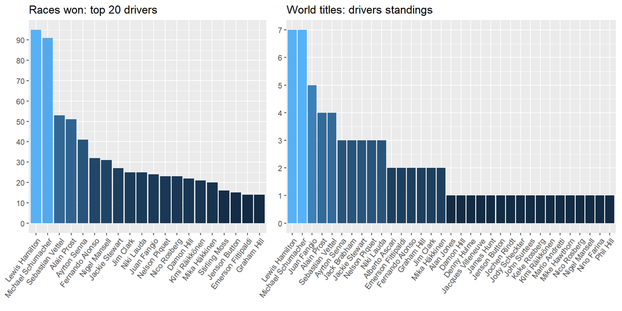

A significant metric in evaluating a driver’s skill is the *amount of points* cumulated during their career. However, there is a problem: *scoring systems* have changed over the years, so it is a little unfair to draw too many conclusions by simply considering the sum of total points scored by each driver. In the following plot whe can see how points system have changed during the history of Formula One.

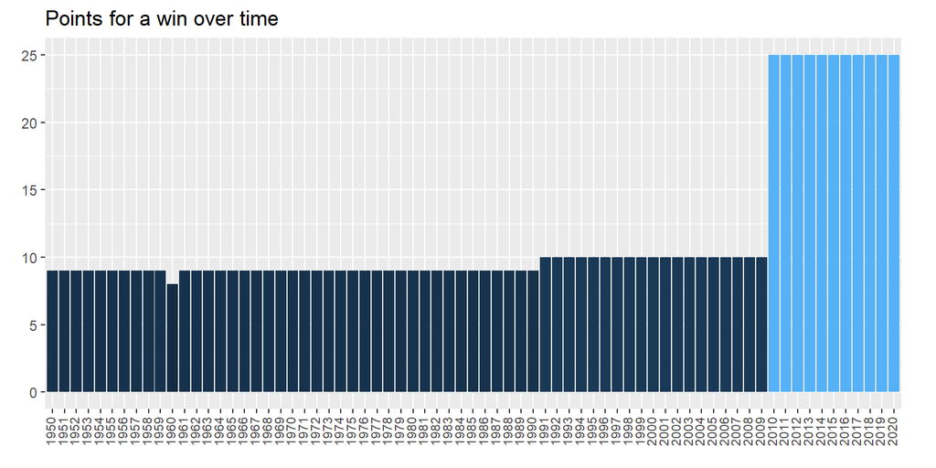

You can see the significant step in maximum points available in 2010 when the points changed from 10 points for a win to 25. It’s clear how evaluating drivers on the basis of the total points would be a dishonest method towards the pilots prior to 2010.

A more fair approach is the following: recalculate the points awarded by drivers for each race in the history of Formula 1 always using the same scoring system. To normalize data we will use the currently used score system (but whithout the *fastest lap bonus point* rule, introduced in 2019). The points are awarded for the top 10 drivers in the following pattern: 1st gets 25, 2nd gets 18,15,12,10,8,6,4,2,1. The following two graphs show the ranking of the drivers by total points, before and after the data normalization.

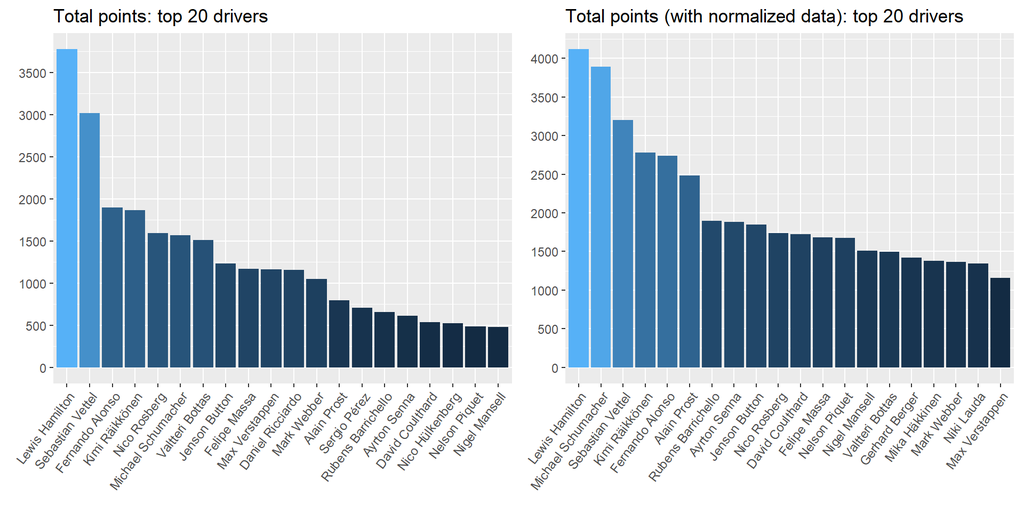

As you can see the results still has Hamilton dominating the standings. However, Michael Schumacher is now much closer a few more drivers from outside of the recent years have started to be included.

The results of the 1047 races for each driver allow us to calculate other useful metrics of performance as well, such as: *number of podiums* and *number of pole positions*. In motorsports, the *pole position* is the position at the inside of the front row at the start of a racing event. This position is typically given to the vehicle and driver with the best qualifying time in the trials before the race (the leader in the starting grid). This number-one qualifying driver is referred to as the *pole-sitter*. With *number of podiums* we mean *wins+2nd+3rd*.

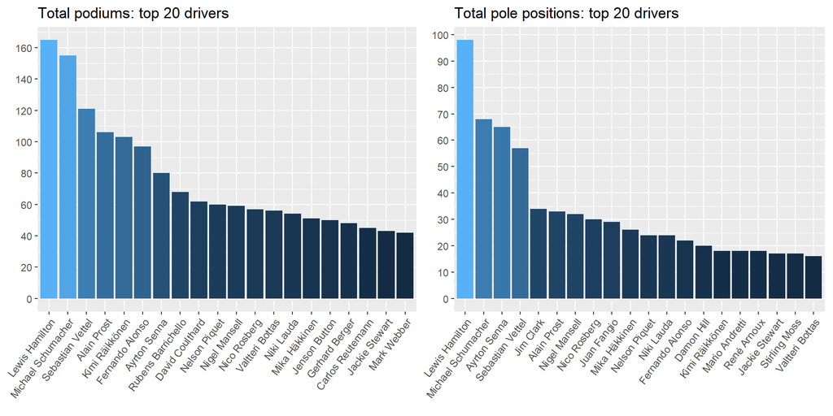

Similarly to the problem previously highlighted, related to the different scoring systems for different years, the metrics illustrated (*wins,podiums,pole positions and total points*) are also influenced by a variability factor dependent on the years: the number of races for each season has varied over the years. So for example, if driver *a* partecipated only in a season with 10 races, and driver *b* partecipated only in a season with 20 races, pilot *b* had double the chance of winning races and so on. A more fair approach is to consider the ratios between *frequency/potential*. New performance metric are calculated in order to make the number of *held races* irrelevant:

- $win \; rate = \frac{wins}{held \; races}$
- $podium \; rate = \frac{podiums}{held \; races}$
- $points \; rate = \frac{tot \; points \; normalized}{tot \; points \; potential}$
- $pole \; rate = \frac{pole \; positions}{held \; races}$

We need to set a requirement in order for a driver to be admitted in the comparison. If a driver won 1 race out of 1, starting in pole positions, he would be placed first in every classification, even if he is an irrelevant driver in the history of F1. The requirement to be included in the comparison is to have participated in at least 20 races (about 1 season).

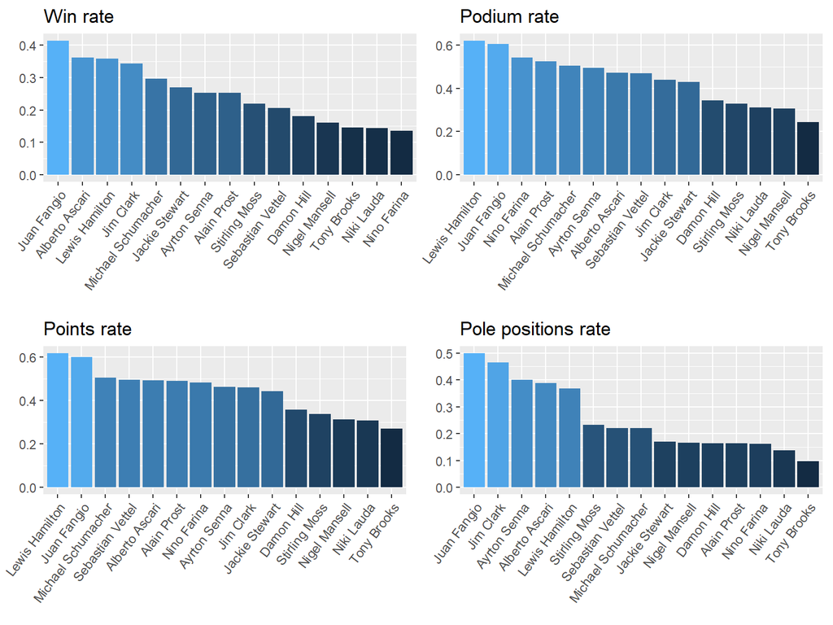

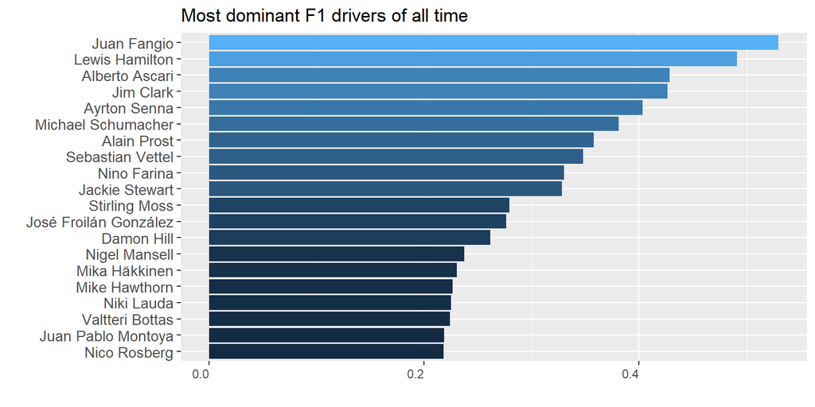

Another factor which can be considered is the fact that car reliability improved over time, so modern driver have an advantage in their ratio statistics. Consider this example: driver *a* and driver *b* started both 100 races. Driver *a* is from the 50s and had 40 mechanical failures, so his real win potential is 60. Driver *b* is a recent *F1* driver, and had only 5 mechanical failurs, so his real win potential is 95. A fairer approach would take this issue into account, and for example, the *win rate* would be calculated in relation to completed races and not based on the races started. The graph below shows how old cars had a higher probability of mechanical failure.

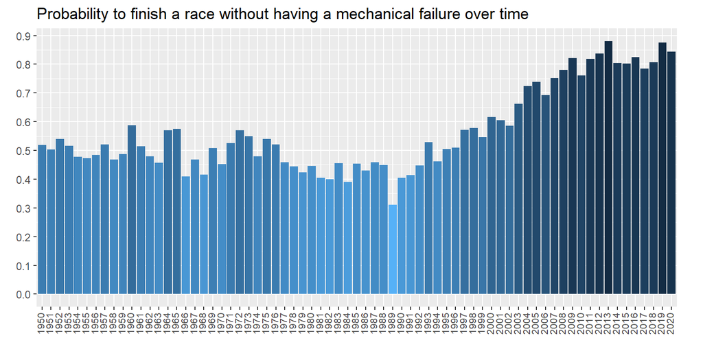

We can clearly see how modern drivers have had, in proportion to the races started, much fewer retirements due to mechanical problems, therefore, they have an advantage in the calculation related to the metrics previously used for *performance* metric. We can fix this problem by introducing a performance multiplier for each driver, calcualted as follow:

$$bonus = \frac{number \; of \; retirements \; due \; to \; mechanical \; failures}{held \; races}$$

And then we can calculate again their performance score, simply by applying the mechanical failures bonus: $new \; performance = (1+bonus) * performance$. The new ranking is the following:

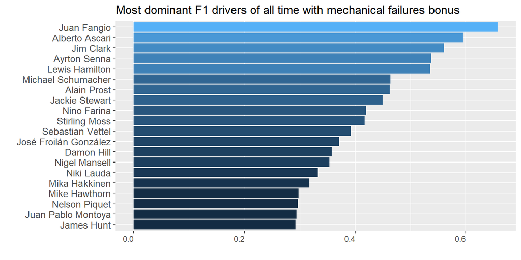

Interestingly by taking this approach the list is dominated by past drivers and not by modern ones. The choiche to include the reliability (mechanical failures) bonus is questionable: some might say that the number of retirements due to mechanical failures does not totally depend on the car reliability but also on the driver’s ability to drive it, therefore a bettere analysis should be performed in this regard.

Recap of driver’s metrics (drivers with at least 20 held races):

| Driver | Nationality | Races started | Races completed | Retirements | Wins | Win rate | 2nd | 3rd | Podiums | Podium rate | Points scored | Points scored (normalized data) | Points rate | Pole positions | Pole rate | 2nd in grid | Performance | Performance with mec. fail bonus |
| --- | --- | --- | --- | --- | --- | --- | --- | --- | --- | --- | --- | --- | --- | --- | --- | --- | --- | --- |
| Juan Fangio | Argentina | 58 | 44 | 14 | 24 | 0.4138 | 10 | 1 | 35 | 0.6034 | 279.14 | 873 | 0.6021 | 29 | 0.5 | 13 | 0.5298 | 0.6577 |
| Alberto Ascari | Italy | 36 | 22 | 14 | 13 | 0.3611 | 4 | 0 | 17 | 0.4722 | 140 | 443 | 0.4922 | 14 | 0.3889 | 7 | 0.4286 | 0.5953 |
| Jim Clark | UK | 73 | 50 | 23 | 25 | 0.3425 | 1 | 6 | 32 | 0.4384 | 274 | 839 | 0.4597 | 34 | 0.4658 | 8 | 0.4266 | 0.561 |
| Ayrton Senna | Brazil | 162 | 108 | 54 | 41 | 0.2531 | 23 | 16 | 80 | 0.4938 | 614 | 1881 | 0.4644 | 65 | 0.4012 | 22 | 0.4031 | 0.5375 |
| Lewis Hamilton | UK | 266 | 242 | 24 | 95 | 0.3571 | 40 | 30 | 165 | 0.6203 | 3778 | 4119 | 0.6194 | 98 | 0.3684 | 60 | 0.4913 | 0.5356 |
| Michael Schumacher | Germany | 308 | 241 | 67 | 91 | 0.2955 | 43 | 21 | 155 | 0.5032 | 1566 | 3890 | 0.5052 | 68 | 0.2208 | 48 | 0.3812 | 0.4641 |
| Alain Prost | France | 202 | 143 | 59 | 51 | 0.2525 | 35 | 20 | 106 | 0.5248 | 798.5 | 2483 | 0.4917 | 33 | 0.1634 | 53 | 0.3581 | 0.4627 |
| Jackie Stewart | UK | 100 | 63 | 37 | 27 | 0.27 | 11 | 5 | 43 | 0.43 | 360 | 1109 | 0.4436 | 17 | 0.17 | 16 | 0.3284 | 0.4499 |
| Nino Farina | Italy | 37 | 27 | 10 | 5 | 0.1351 | 9 | 6 | 20 | 0.5405 | 127.33 | 447 | 0.4832 | 6 | 0.1622 | 11 | 0.3303 | 0.4195 |
| Stirling Moss | UK | 73 | 37 | 36 | 16 | 0.2192 | 5 | 3 | 24 | 0.3288 | 186.5 | 616 | 0.3375 | 17 | 0.2329 | 9 | 0.2796 | 0.4175 |

[output cut: 240 more lines]

### Conclusions on the analysis of drivers

Through data analysis we were able to evaluate driver’s performance on the basis of multiple metrics. Those metrics allowed us to define a more sophisticated ranking system which, based on some assumptions, allowed us to isolate some variabilty factors relating to the changes that have occurred over the decades, allowing us to perform a more honest and objective assessment.

# What if we had to give a flag to F1?

Formula One is an international motorsport, but which country was the most present one during these 71 years? Let’s find out through the data we have available. Checking the nationality of the 850 drivers, 211 manufacturers and 74 circuits, we count a total of 49 nations involved in this motorsport. Let’s visualize the 6 countries with the highest number per category:

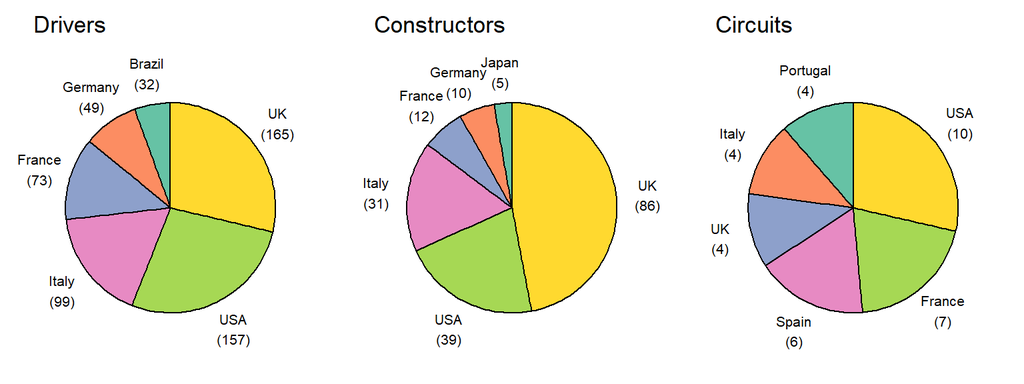

For each of these categories we can extract more meaningful information. We count the total number of races disputed by drivers from each nation, constructors’ championships, and the number of race weekends for circuits divided by nationality. In this way we move from a simple count to a measure of the presence of each nation.

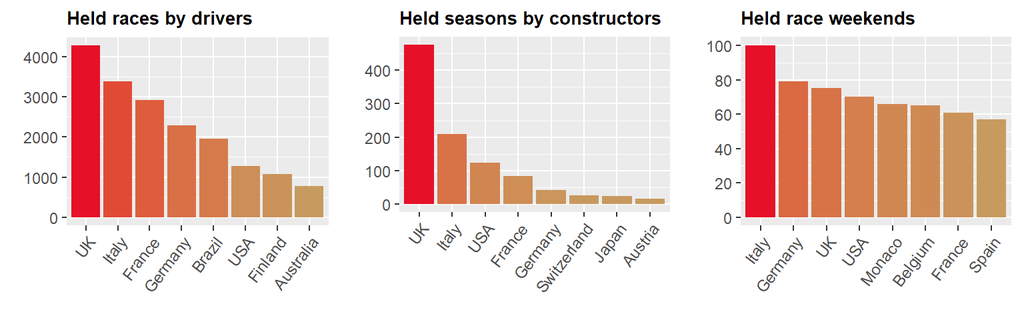

We can already see how United Kingdom has a very high number of drivers and constructors. If we set up a weighting system based on those three metrics we can decide which nation has been most present throughout the history of F1. We will use the following weights:

- $number \; of \; race \; weekends = 0.3$;
- $races \; held \; by \; drivers = 0.4$;
- $seasons \; held \; by \; constructors = 0.3$;

So the score for each country is computed as follow:

$$score = \frac{3}{10}*number \; of \; race \; weekends + \frac{4}{10}*races \; held \; by \; drivers + \frac{3}{10}*seasons \; held \; by \; constructors$$
We summarize our results with the following *wordcloud* where the dimension of each *contry* depends on its *score*.

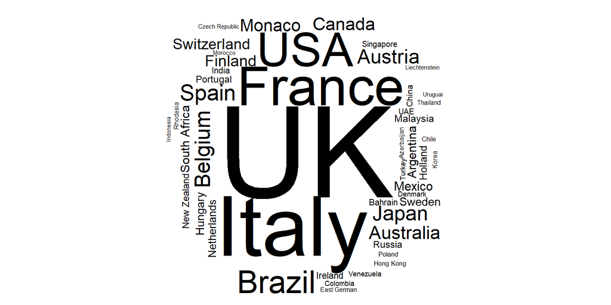

We will now visualize our results through a *heatmap*:

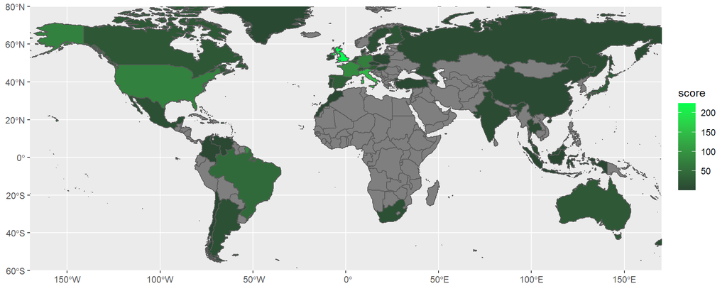

Let’s have a clooser look into Europe:

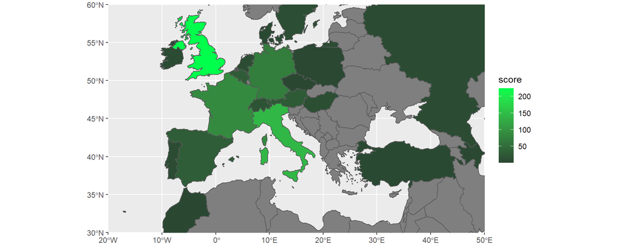

| Country | Score | Circuitrs | Race weekends | Drivers | Held races by drivers | Constructors | Held seasons by constructors |
| --- | --- | --- | --- | --- | --- | --- | --- |
| UK | 223.77 | 4 | 75 | 165 | 4286 | 86 | 476 |
| Italy | 141.96 | 4 | 100 | 99 | 3396 | 31 | 209 |
| France | 87.95 | 7 | 61 | 73 | 2916 | 12 | 84 |
| USA | 75.52 | 10 | 70 | 157 | 1279 | 39 | 124 |
| Germany | 71.18 | 3 | 79 | 49 | 2296 | 10 | 41 |
| Brazil | 47.17 | 2 | 47 | 32 | 1953 | 1 | 8 |
| Spain | 29.13 | 6 | 57 | 15 | 734 | 1 | 3 |
| Belgium | 28.59 | 3 | 65 | 23 | 591 | 1 | 1 |
| Japan | 26.92 | 3 | 37 | 19 | 591 | 5 | 24 |
| Austria | 25.4 | 3 | 34 | 15 | 690 | 1 | 16 |

[output cut: 39 more lines]